# Spatial residencial segregation in Maryland

### Spatial Indices

```python
from libpysal import weights
```

```python
from segregation.spatial import SpatialDissim,  SpatialInformationTheory
```

```python
w_queen = weights.Queen.from_dataframe(mary)
w_dist = weights.DistanceBand.from_dataframe(mary, 2500)
```

### Single Group

```python
spatial_dissim = SpatialDissim(mary, 'NHB', 'POP100', w=w_queen)
```

```python
spatial_dissim.statistic
```

```
0.48163752870534443
```

### Multi Group

we can also look at how different concepts of space influence the resulting index statistic

```python
spatial_info_queen = SpatialInformationTheory(mary, pop_groups, w=w_queen)
spatial_info_dist = SpatialInformationTheory(mary, pop_groups, w=w_dist)
```

```python
spatial_info_queen.statistic
```

```
0.24691498678209223
```

```python
spatial_info_dist.statistic
```

```
0.32474243646699963
```

### Multiscalar Profile

The multiscalar segregation profile is a way of measuring how global versus local the segregation patterns are in a region.

```python
from segregation.spatial import compute_segregation_profile
```

```python
distances = [1500., 2500., 3500., 4500., 5500.]
```

```python
prof = compute_segregation_profile(mary, pop_groups, distances)
```

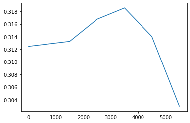

```python
import pandas as pd
pd.Series(prof).plot()
```

We can also look at how the segregation profiles differ by region. If we plot them all on the same graph, we can compare the slopes of the lines to see how the shape of segregation differs between places in the Maryland region

```python
coastal_prof = compute_segregation_profile(coastal, pop_groups, distances)
inland_prof = compute_segregation_profile(inland, pop_groups, distances)
```

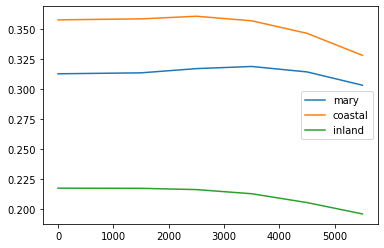

```python
pd.Series(prof, name='mary').plot(legend=True)
pd.Series(coastal_prof, name='coastal').plot(legend=True)
pd.Series(inland_prof, name='inland').plot(legend=True)
```

This shows that segregation in the coastal region is considerably larger than the inland region at every scale, though have similar shapes to their overall segregation profiles.

### Single-Value Inference

```python
from segregation.inference import SingleValueTest
```

```python
entropy_test = SingleValueTest(entropy)
```

```python
dissim_test = SingleValueTest(dissim)
```

```python
entropy_test.p_value
```

```
0.0
```

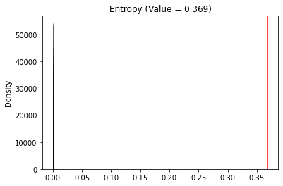

```python
entropy_test.plot()
```

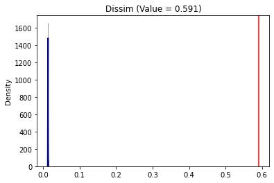

```python
dissim_test.plot()
```

### Comparative Inference

```python
from segregation.inference import TwoValueTest
```

```python
info_test = TwoValueTest(MultiInformationTheory(coastal, pop_groups),
            MultiInformationTheory(inland, pop_groups))
```

```python
info_test.est_point_diff
```

```
0.14021040416660532
```

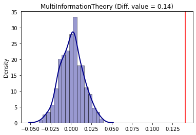

```python
info_test.plot()
```

### Decomposition

A popular approach to the analysis of inequality is to group the observations into mutually exclusive and exhaustive subsets in order to understand how much of the inequality is due to differences between members of the same subset versus between observations from different subsets.

```python
from segregation.decomposition import DecomposeSegregation
```

```python
w_coastal = weights.DistanceBand.from_dataframe(coastal, 2000)
```

```python
w_inland = weights.DistanceBand.from_dataframe(inland, 2000)
```

```python
decomp = DecomposeSegregation(SpatialDissim(coastal, 'NHB', 'POP100', w=w_coastal),
                    SpatialDissim(inland,'HISP', 'POP100', w=w_inland))
```

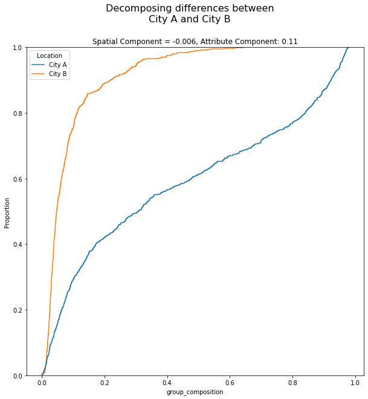

```python
decomp.plot()
```

### County that has greatest level of multiracial segregation based on Multi Information Theory

```python
results = {}

for i in mary.county.unique():

    results[i] = MultiInformationTheory(mary[mary.county==i], pop_groups).statistic
    print(f"{i} Info Theory: {results[i]}")
```

```
Allegany Info Theory: 0.02853353450772709
Anne Arundel Info Theory: 0.0811819310878695
Baltimore County Info Theory: 0.09297668907501305
Baltimore Info Theory: 0.36925893622763384
Calvert Info Theory: 0.20456228772225765
Caroline Info Theory: 0.15898502468689088
Carroll Info Theory: 0.13293466324742778
Cecil Info Theory: 0.07781090089146425
Charles Info Theory: 0.07127611790381823
Kent Info Theory: nan
Talbot Info Theory: 0.1798476685371681
Dorchester Info Theory: 0.22899916566631906
Montgomery Info Theory: 0.2514049869735716
Washington Info Theory: 0.1584747748740138
Frederick Info Theory: 0.13793424216633307
Prince George's Info Theory: 0.04016527998692056
Wicomico Info Theory: 0.08335499069470388
Garrett Info Theory: 0.13323311689090303
Harford Info Theory: 0.04342940624917927
St. Mary's  Info Theory: 0.15501176192679625
Howard Info Theory: 0.13258515628299858
Somerset Info Theory: 0.14096632203781584
Queen Anne's Info Theory: 0.022986811956981004
Worcester Info Theory: 0.07891935093456766
```

```
Baltimore Gini: 0.8065999731627469
Montgomery Gini: 0.7363593459846585
```

```
test significance level = 0.0
```

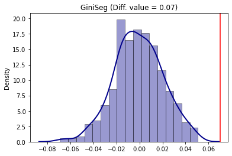

```python
bside_gini = GiniSeg(mary[mary.county=='Baltimore'], group_pop_var='NHB', total_pop_var='POP100')
ment_gini = GiniSeg(mary[mary.county=='Montgomery'], group_pop_var='NHB', total_pop_var='POP100')

print(f"\nBaltimore Gini: {bside_gini.statistic}")
print(f"Montgomery Gini: {ment_gini.statistic}")
ginitest = TwoValueTest(bside_gini, ment_gini)
print(f"test significance level = {ginitest.p_value}")
ginitest.plot()
```

### Check Spatial Dissimilarity index, does the difference in segregation between Baltimore and Montgomery result from the demograpic structure or the spatial structure

```
array([[<AxesSubplot:title={'center':'City A\nOriginal Composition'}>,
        <AxesSubplot:title={'center':'City B\nCounterfactual Composition'}>],
       [<AxesSubplot:title={'center':'City A\nCounterfactual Composition'}>,
        <AxesSubplot:title={'center':'City B\nOriginal Composition'}>]],
      dtype=object)
```

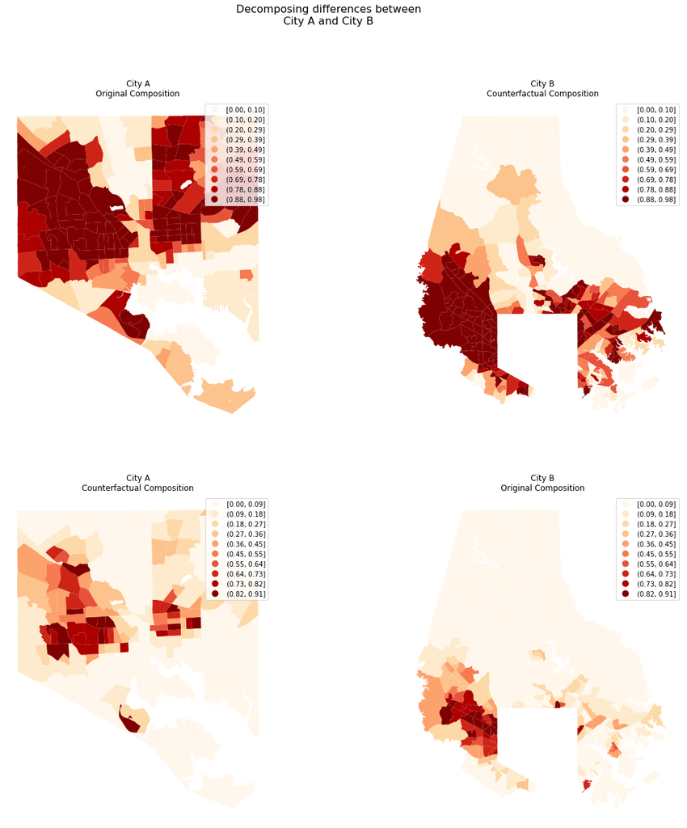

```python
decomp = DecomposeSegregation(SpatialDissim(mary[mary.county=='Baltimore'], group_pop_var='NHB', total_pop_var='POP100'),
                              SpatialDissim(mary[mary.county=='Montgomery'], group_pop_var='NHB', total_pop_var='POP100'))
decomp.plot('maps')
```

from the map we observed that their is spatial difference between this two counties interms of Black people concentration.

# Further reading

1. An open-source framework for non-spatial and spatial segregation measures: the PySAL segregation module [link](https://link.springer.com/article/10.1007/s42001-019-00059-3).
2. PySAL segregation module for spatial indexes [link](https://pysal.org/notebooks/explore/segregation/spatial_examples.html#PySAL-*segregation*-module-for-spatial-indexes)
3. Spatial Inequality [link](https://geographicdata.science/book/notebooks/09_spatial_inequality.html).

# Conclusion

# Next Step

There is still much room to further study. For example, you can further investigate racial segregation for individual cities.